# R Notebook

###**Simulations of Distributions, the CLT, and the LLN**

### Simulating Poisson Distributions

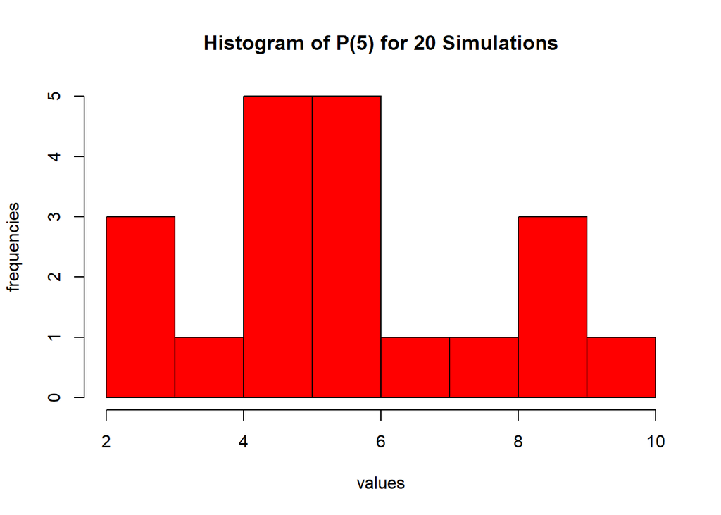

```r
# Generate 20 random variables from the Poisson distribution with lambda = 5, and do this for 50 random variables, and then finally for a large number

set.seed(42)

pois_data = rpois(20, 5)

sim1_pois = rpois(50, 5)

sim2_pois = rpois(1000, 5)

# Histograms

hist(pois_data, col = "red", xlab="values", ylab="frequencies", main="Histogram of P(5) for 20 Simulations")
```

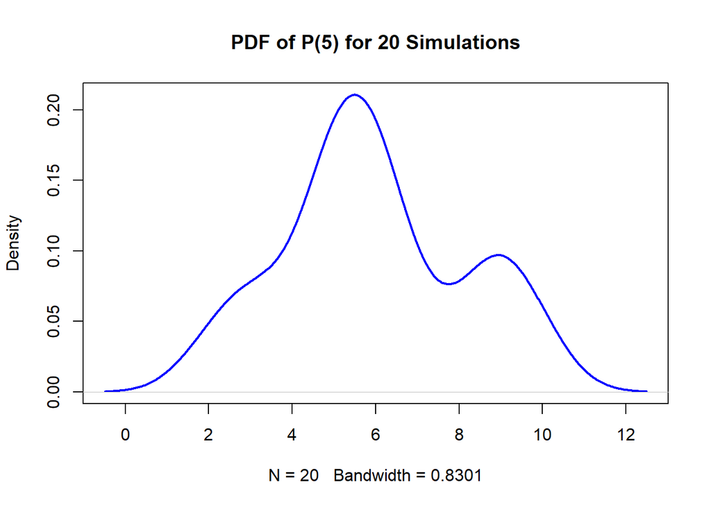

```r
plot(density(pois_data), col="blue", lwd=2,
     main= "PDF of P(5) for 20 Simulations")
```

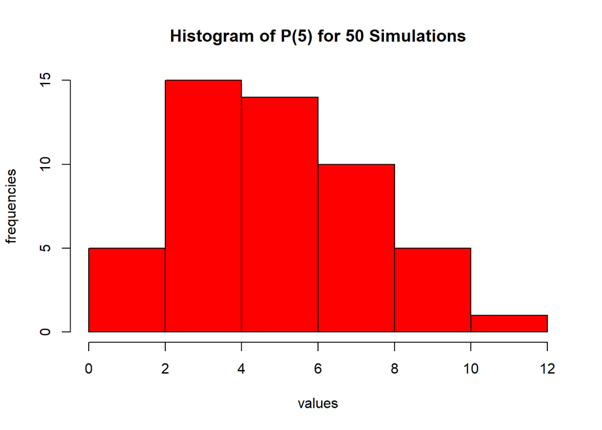

```r
hist(sim1_pois, col = "red", xlab="values", ylab="frequencies", main="Histogram of P(5) for 50 Simulations")
```

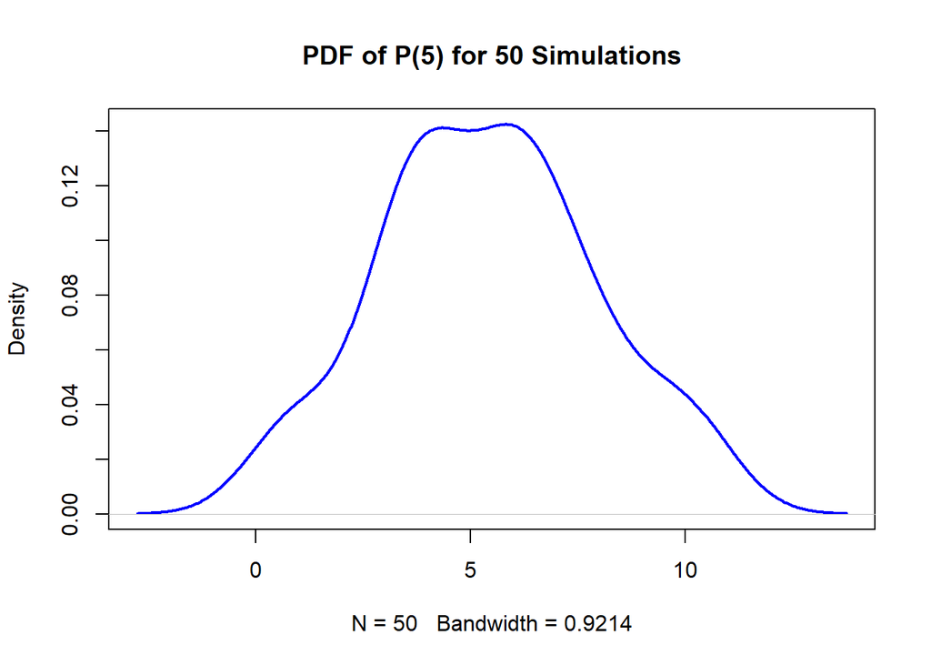

```r
plot(density(sim1_pois), col="blue", lwd=2,
     main= "PDF of P(5) for 50 Simulations")
```

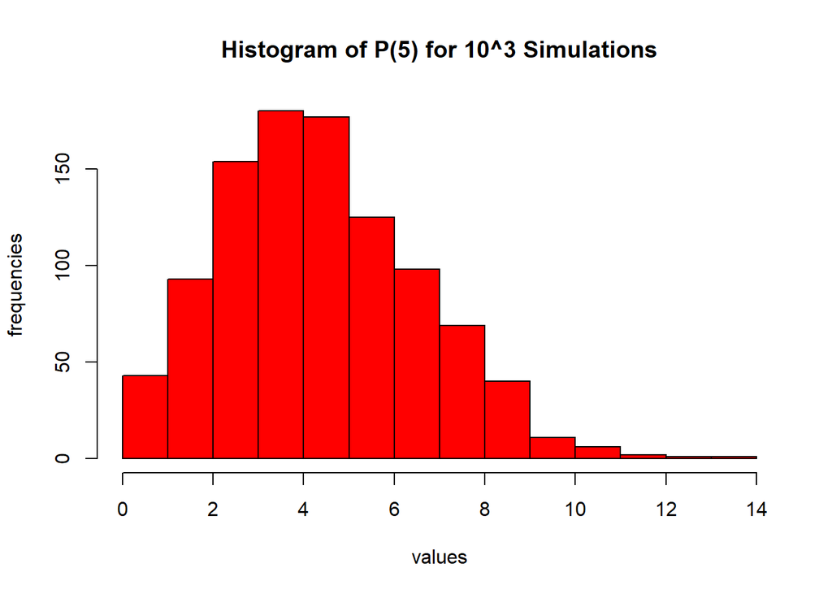

```r
hist(sim2_pois, col = "red", xlab="values", ylab="frequencies", main="Histogram of P(5) for 10^3 Simulations")
```

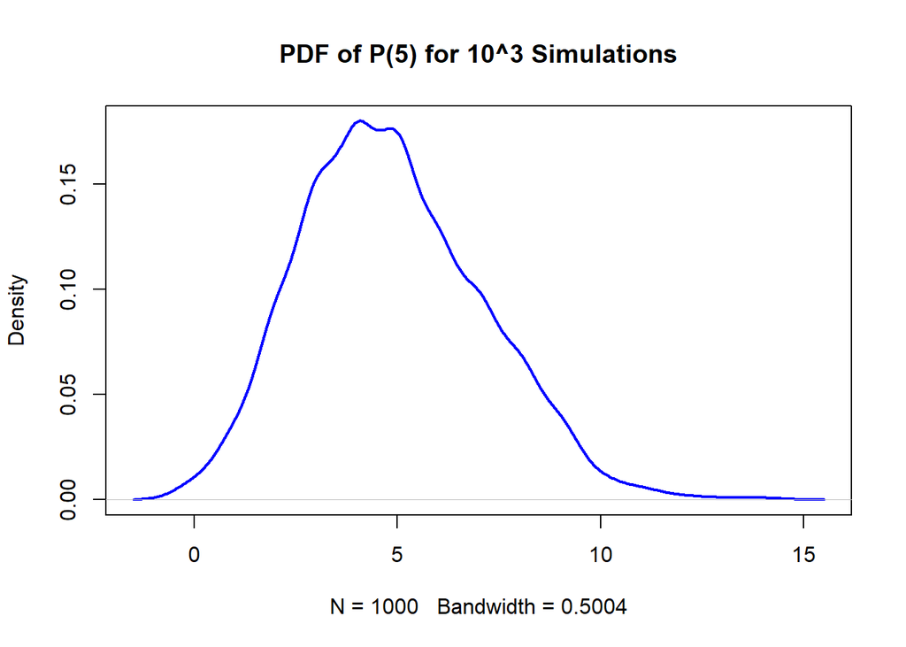

```r
plot(density(sim2_pois), col="blue", lwd=2,
     main= "PDF of P(5) for 10^3 Simulations")
```

Both the histograms and density curves for each of the simulations are providing us a pattern.

Some useful commands:

```r
# Continuing with the previous simulation, let's investigate the probabilities.

# P(X<=2)

ppois(2, 5)
```

```
## [1] 0.124652
```

```r
# P(X=1)

dpois(1,5)
```

```
## [1] 0.03368973
```

```r
# P(X<x) = 0.03368973 (Finding the quantile)

qpois(0.03368973, 5)
```

```
## [1] 1
```

Now let’s check the parameters.

```r
mean(rpois(20,5))
```

```
## [1] 4.9
```

```r
mean(rpois(50,5))
```

```
## [1] 4.98
```

```r
mean(rpois(1000, 5))
```

```
## [1] 4.999
```

The sample means are now converging (approaching) to the population mean of 5.

### Simulating Normal Distributions

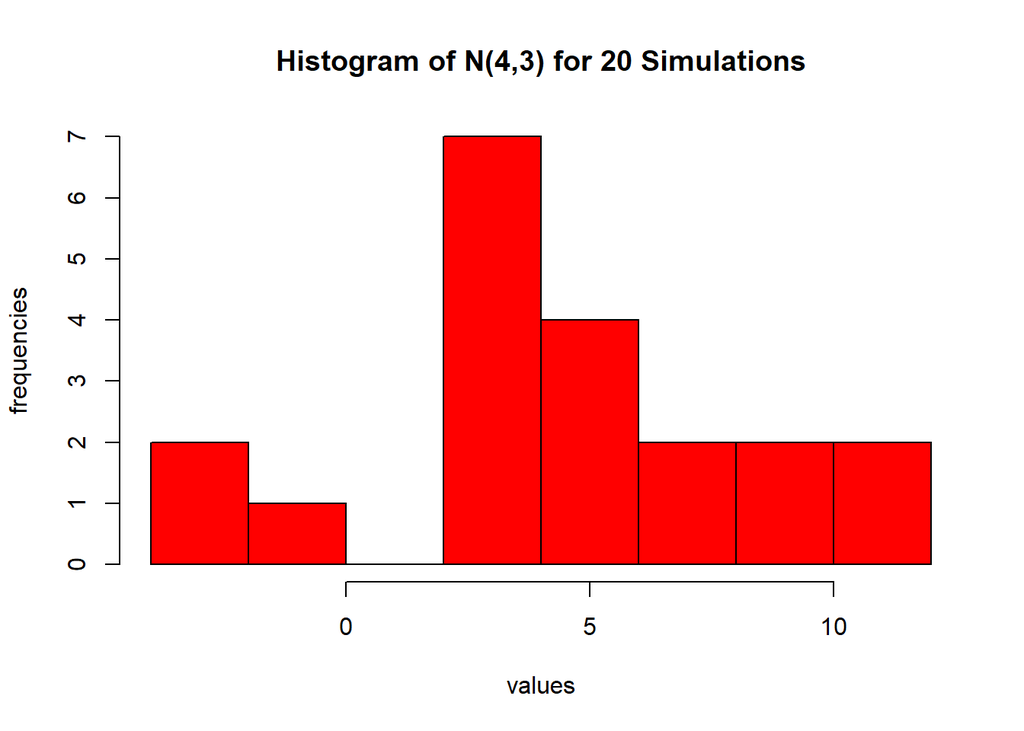

```r
set.seed(42)

norm_data = rnorm(20, mean=4, sd=3)

sim1_norm = rnorm(50, mean=4, sd=3)

sim2_norm = rnorm(1000, mean=4, sd=3)

# Histograms

hist(norm_data, col = "red", xlab="values", ylab="frequencies", main="Histogram of N(4,3) for 20 Simulations")
```

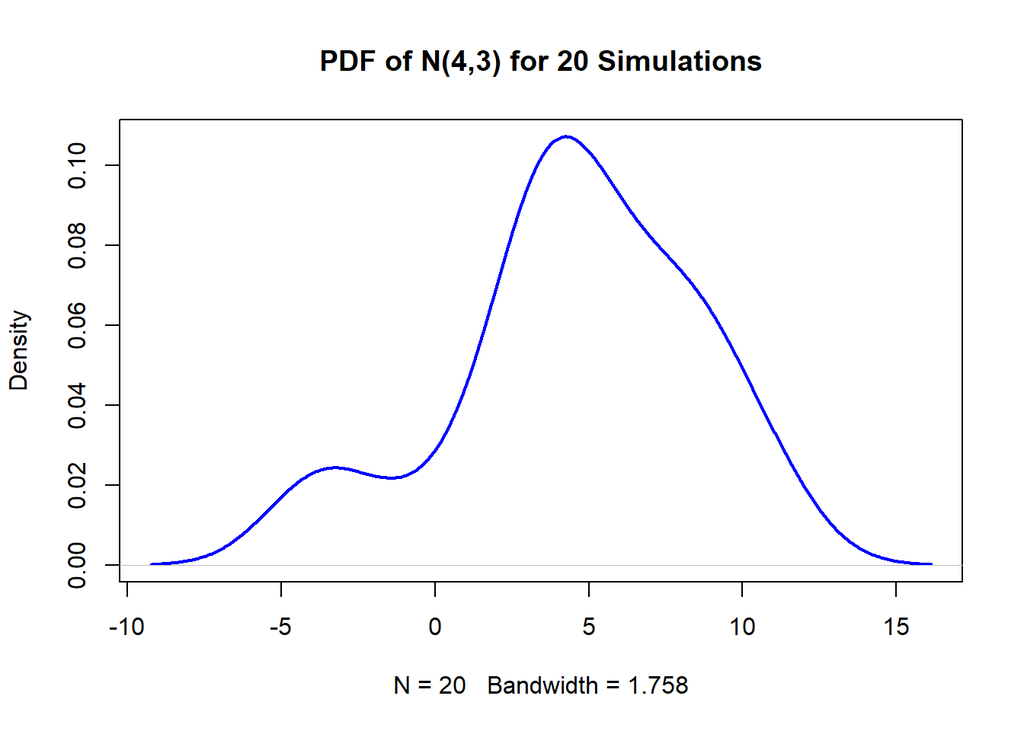

```r
plot(density(norm_data), col="blue", lwd=2,
     main= "PDF of N(4,3) for 20 Simulations")
```

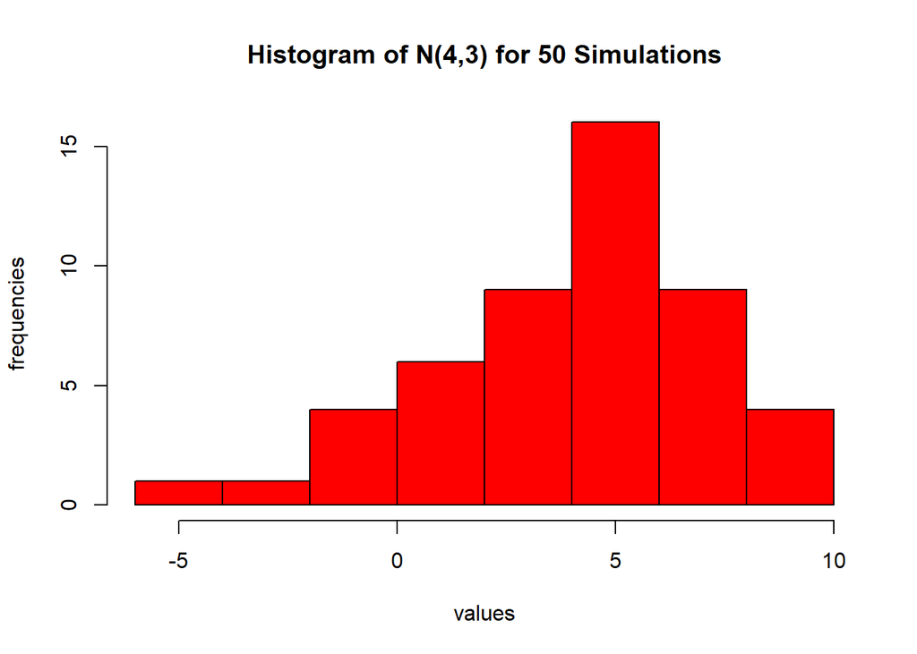

```r
hist(sim1_norm, col = "red", xlab="values", ylab="frequencies", main="Histogram of N(4,3) for 50 Simulations")
```

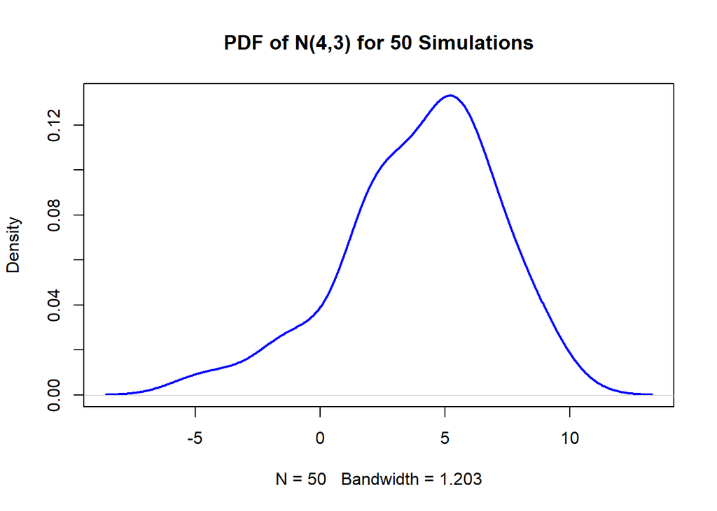

```r
plot(density(sim1_norm), col="blue", lwd=2,
     main= "PDF of N(4,3) for 50 Simulations")
```

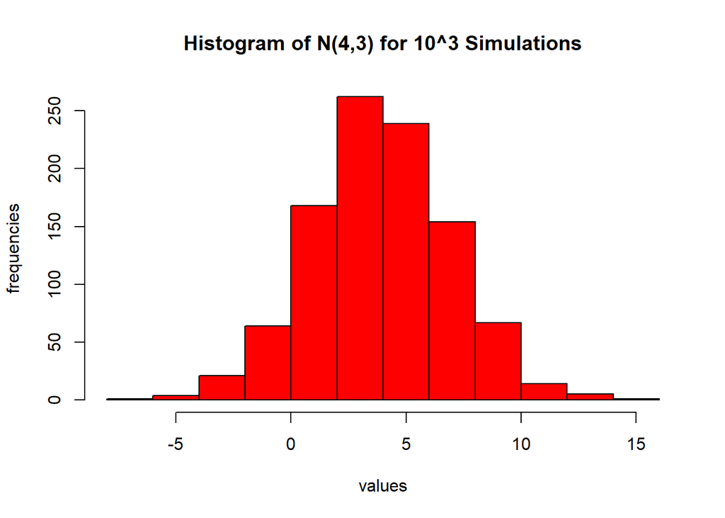

```r
hist(sim2_norm, col = "red", xlab="values", ylab="frequencies", main="Histogram of N(4,3) for 10^3 Simulations")
```

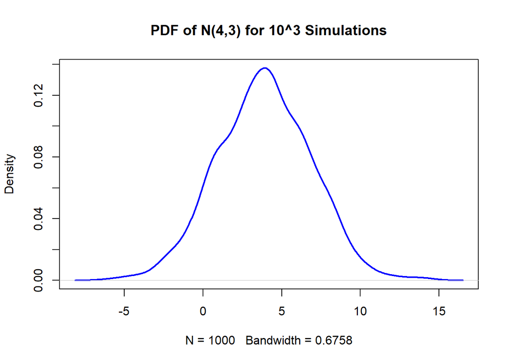

```r
plot(density(sim2_norm), col="blue", lwd=2,
     main= "PDF of N(4,3) for 10^3 Simulations")
```

```r
# Checking parameter values

mean(norm_data)
```

```
## [1] 4.57576
```

```r
mean(sim1_norm)
```

```
## [1] 3.997163
```

```r
mean(sim2_norm)
```

```
## [1] 3.884576
```

The two simulations of the Normal and Poisson distributions illustrate the magic of the CLT and LLN from a data-driven perspective. Let’s take a look at some other practical examples.

You can superimpose plots like so:

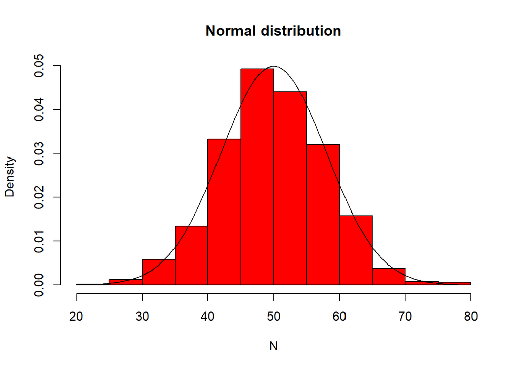

```r
set.seed(42)
N = rnorm(1000, mean=50, sd=8)# simulate n=1000 from N(50,25)
hist(N, probability=TRUE,col="red",main="Normal distribution")
N.1 = seq(min(N), max(N), length=100)
lines(N.1, dnorm(N.1, mean=50, sd=8))
```

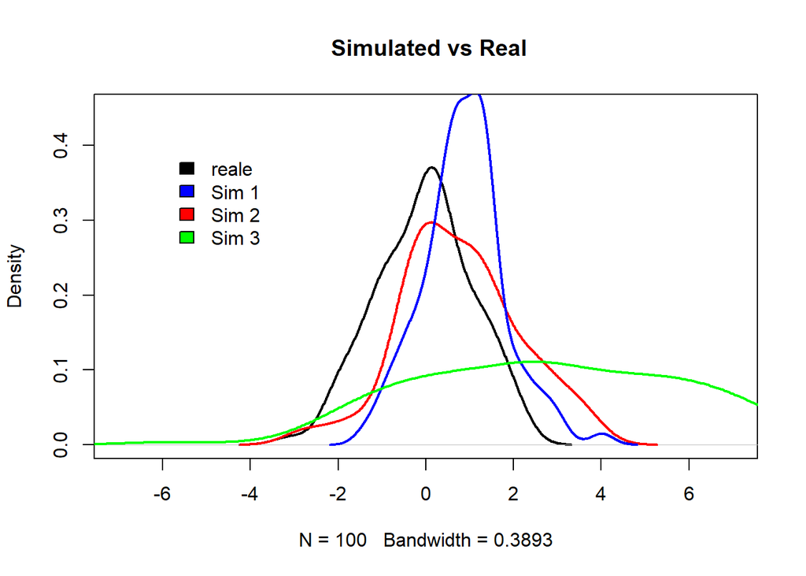

```r
set.seed(512)
x=rnorm(100,0,1)# real observations
plot(density(x),main=" Simulated vs Real",lwd=2,xlim=c(-7,7),ylim=c(0,0.45))

x1=rnorm(100,0.5,1.5)# simulate 100 observations from N(0.5,1.5)
lines(density(x1),col="red",lwd=2)# plot x1

x2=rnorm(100,1,1)#simulate 100 observations from N(1,1)
lines(density(x2),col="blue",lwd=2)# plot x2

x3=rnorm(100,3,3)#simulate 100 observations from N(3,3)
lines(density(x3),col="green",lwd=2)# plot x3

legend(-6,0.4,c("reale","Sim 1","Sim 2","Sim 3"),fill=c("black","blue","red","green"),box.col="white")
```

### Simulating the CLT and LLN

```r
library(tidyverse)
```

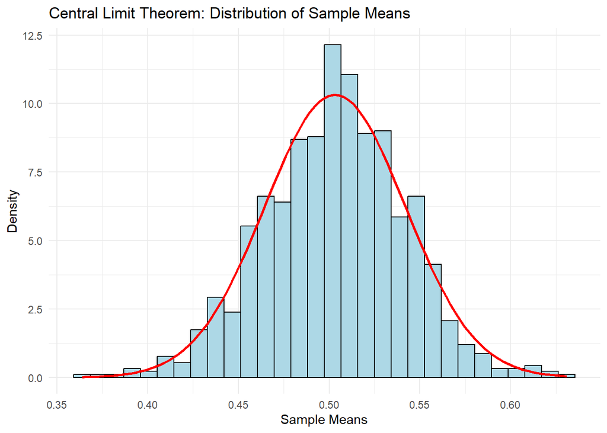

```r
# Simulate sampling from a uniform distribution
n_samples = 1000
sample_size = 50
uniform_samples = replicate(n_samples,
                             mean(runif(sample_size,
                                                   min = 0, max = 1)))

# Create a data frame for plotting
clt_data = data.frame(Sample_Mean = uniform_samples)

# Plot using ggplot2
ggplot(clt_data, aes(x = Sample_Mean)) +
  geom_histogram(aes(y = ..density..),
    bins = 30,
    fill = "lightblue",
    color = "black"
  ) +
  stat_function(
    fun = dnorm, args = list(
      mean = mean(uniform_samples),
      sd = sd(uniform_samples)
    ),
    color = "red", size = 1
  ) +
  labs(
    title = "Central Limit Theorem: Distribution of Sample Means",
    x = "Sample Means",
    y = "Density"
  ) +
  theme_minimal()
```

### Simulating Mixture Distributions: The Discrete Case

```r
set.seed(42)

# Define the parameters of the discrete mixture distribution
# Example: a mixture of two Poisson distributions

# Component 1: Poisson with lambda = 2
lambda1 = 2
# Component 2: Poisson with lambda = 10
lambda2 = 10

# Mixture proportions
# 70% from component 1, 30% from component 2
mix_probs = c(0.7, 0.3)

# Number of samples to generate
n_samples = 1000

# Initialize an empty vector to store the samples
mixture_samples = numeric(n_samples)

for (i in 1:n_samples) {
  # Step 1: Choose a component based on mixture proportions
  # sample() with prob argument selects an index based on the probabilities
  chosen_component_index = sample(1:length(mix_probs), 1, prob = mix_probs)

  # Step 2: Sample from the chosen discrete distribution
  if (chosen_component_index == 1) {
    mixture_samples[i] = rpois(1, lambda = lambda1) # Sample from Poisson 1
  } else {
    mixture_samples[i] = rpois(1, lambda = lambda2) # Sample from Poisson 2
  }
}

# View the first few samples
head(mixture_samples)
```

```
## [1] 14 11  6  3  7  6
```

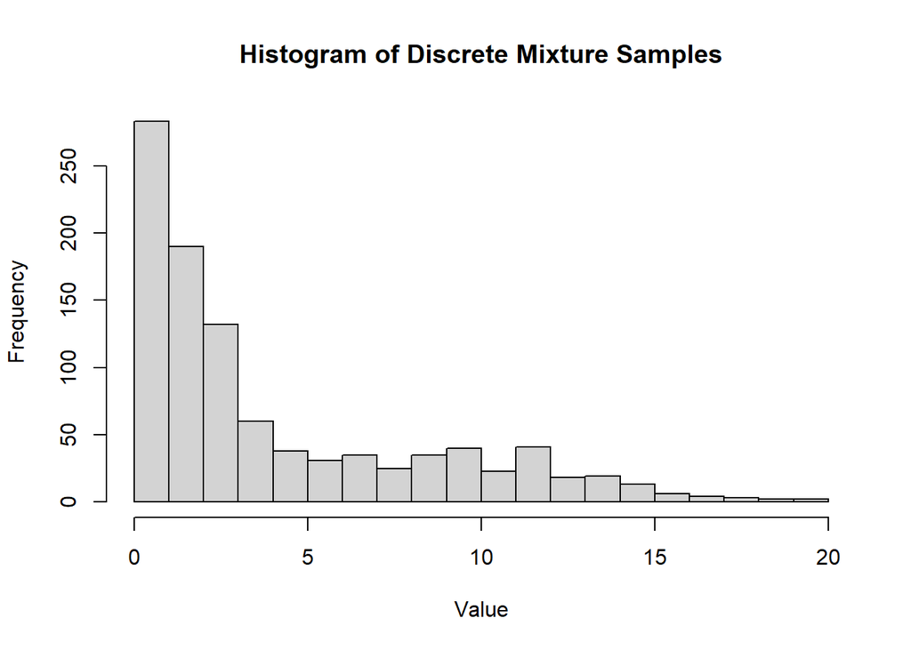

```r
# Visualize the distribution of the samples
hist(mixture_samples, breaks = max(mixture_samples) + 1,
     main = "Histogram of Discrete Mixture Samples",
     xlab = "Value", ylab = "Frequency")
```

### Simulating Mixture Distributions: The Continuous Case Using Transformations

```r
# Chi-Square

set.seed(42)

n = 1000
nu = 2
X = matrix(rnorm(n*nu), n, nu)^2
y = rowSums(X)
mean(y)
```

```
## [1] 1.976083
```

```r
mean(y^2)
```

```
## [1] 8.05964
```

Here is an example of a mixture distribution of two Normals.

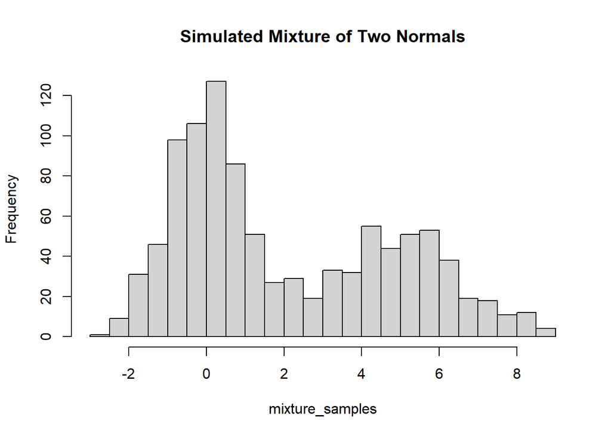

```r
n = 1000 # Number of samples
mix_probs = c(0.6, 0.4) # Mixing probabilities
means = c(0, 5) # Means of the two normal components
sds = c(1, 1.5) # Standard deviations of the two normal components

# Generate component labels
component_labels = sample(1:2, size = n, replace = TRUE, prob = mix_probs)

# Initialize vector for mixture samples
mixture_samples = numeric(n)

# Sample from each component based on labels
for (i in 1:n) {
  if (component_labels[i] == 1) {
    mixture_samples[i] = rnorm(1, mean = means[1], sd = sds[1])
  } else {
    mixture_samples[i] = rnorm(1, mean = means[2], sd = sds[2])
  }
}

# Plot histogram of the simulated mixture
hist(mixture_samples, breaks = 30, main = "Simulated Mixture of Two Normals")
```

### Simulating Distributions Using the Inverse Transformation Method

The inverse CDF method can simulate distributions and their random samples by mapping samples taken from a Uniform(0,1) distribution to the input values of the original distribution’s CDF. For example, suppose we have an Exponential distribution with lambda=2. The CDF for this distribution is 1-exp(-lambda*x), and its inverse is -ln(1-u) / lambda.

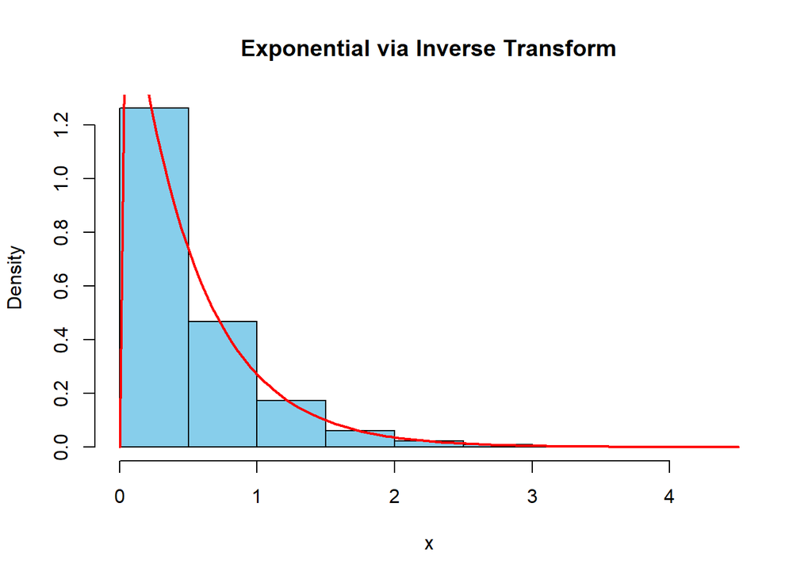

```r
set.seed(42)
n = 10000
lambda = 2

# Step 1: Generate Uniform(0,1)
u = runif(n)

# Step 2: Apply inverse CDF
x = -log(1 - u) / lambda

# Compare with built-in exponential generator
hist(x, probability=TRUE, col="skyblue", main="Exponential via Inverse Transform")
curve(dexp(x, rate=lambda), add=TRUE, col="red", lwd=2)
```

```r
# Inspecting the first few newly sampled values.
head(x)
```

```
## [1] 1.2314124 1.3829092 0.1685339 0.8872967 0.5132559 0.3660438
```

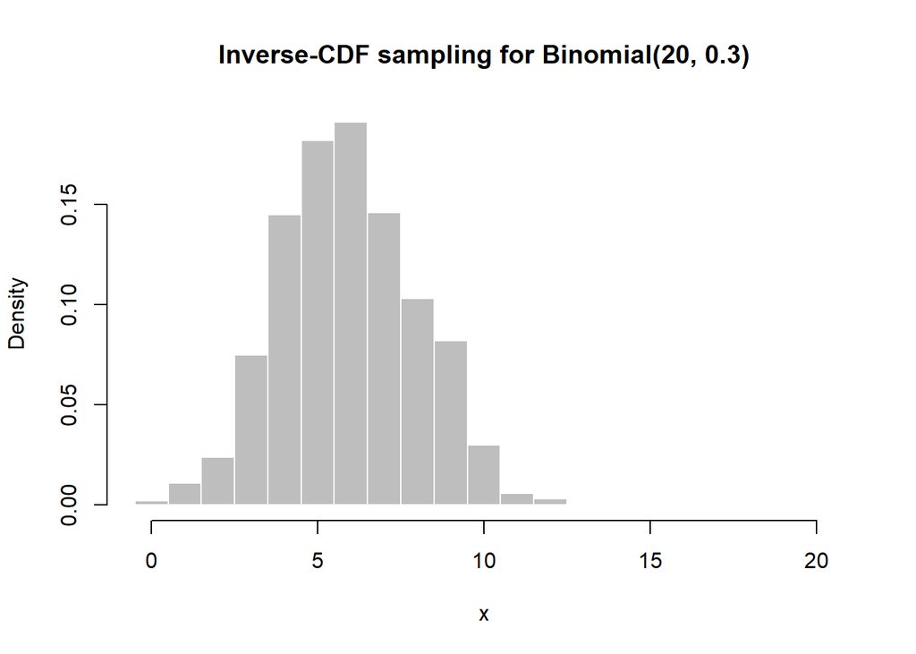

```r
# Binomial Distribution Example

# Here, we use the inverse CDF method to generate random samples from the Binomial Distribution with success probability 0.3

set.seed(42)

N = 1000
n = 20
p = 0.3

# Obtain binomial CDF

x = 0:n
bcdf = pbinom(x, size = n, prob = p)

# Generate uniformly distributed random number from U(0,1)

u   = runif(N)
idx = findInterval(u, bcdf) + 1

# Finding the smallest index j with F(x_j) >= u

idx[idx > length(x)] = length(x)

X = x[idx]

# PMF for comparison

bpdf = dbinom(x, size = n, prob = p)

# Plot: histogram (relative freq) vs pmf
hist(X,
     breaks = seq(-0.5, n + 0.5, 1),
     probability = TRUE,
     col = "grey", border = "white",
     main = "Inverse-CDF sampling for Binomial(20, 0.3)",
     xlab = "x")
```

```r
# Quick numeric check: empirical vs theoretical

relfreq = prop.table(table(factor(X, levels = x)))

cbind(empirical = as.numeric(relfreq), pmf = bpdf)
```

```
##       empirical          pmf
##  [1,]     0.002 7.979227e-04
##  [2,]     0.011 6.839337e-03
##  [3,]     0.024 2.784587e-02
##  [4,]     0.075 7.160367e-02
##  [5,]     0.145 1.304210e-01
##  [6,]     0.182 1.788631e-01
##  [7,]     0.191 1.916390e-01
##  [8,]     0.146 1.642620e-01
##  [9,]     0.103 1.143967e-01
## [10,]     0.082 6.536957e-02
## [11,]     0.030 3.081708e-02
## [12,]     0.006 1.200665e-02
## [13,]     0.003 3.859282e-03
## [14,]     0.000 1.017833e-03
## [15,]     0.000 2.181070e-04
## [16,]     0.000 3.738977e-05
## [17,]     0.000 5.007558e-06
## [18,]     0.000 5.049639e-07
## [19,]     0.000 3.606885e-08
## [20,]     0.000 1.627166e-09
## [21,]     0.000 3.486784e-11
```

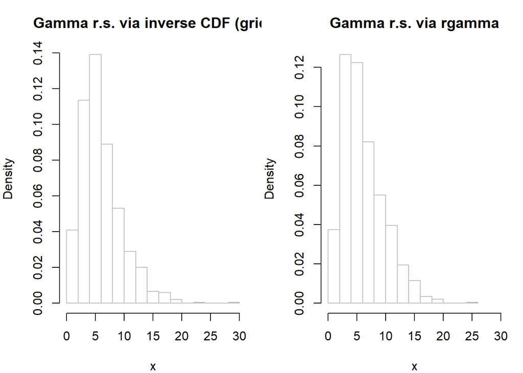

```r
set.seed(1)

# Parameters

N     = 1000
alpha = 3
beta  = 2

# NOTE: this is 'scale' in R (rate = 1/beta)

# True pdf/cdf

x  = seq(0.01, 30, by = 0.01)
y  = dgamma(x, shape = alpha, scale = beta)

# true density
# Fast (analytic) CDF:

mygam_cdf = pgamma(x, shape = alpha, scale = beta)

## ---- Alternative: numeric CDF (slow; mirrors your integral loop) ----
## Uncomment if you want to literally integrate each point.
# mygam_cdf <- sapply(x, function(a)
#   integrate(function(t) dgamma(t, shape = alpha, scale = beta), 0, a)$value)

# Inverse-CDF sampling on the grid
u   = runif(N)
idx = findInterval(u, mygam_cdf) + 1          # first index with CDF >= u
idx = pmin(idx, length(x))                    # guard when u ~ 1
gamrv = x[idx]

# Comparison sample using rgamma
gam_rnd = rgamma(N, shape = alpha, scale = beta)

# Plots

op = par(mfrow = c(1, 2), mar = c(4,4,3,1))

hist(gamrv, breaks = 15, probability = TRUE, col = "white",
     border = "grey", main = "Gamma r.s. via inverse CDF (grid)",
     xlab = "x", xlim = c(0, 30))

hist(gam_rnd, breaks = 15, probability = TRUE, col = "white",
     border = "grey", main = "Gamma r.s. via rgamma",
     xlab = "x", xlim = c(0, 30))
```

```r
par(op)
```

### Simulating Stochastic Processes

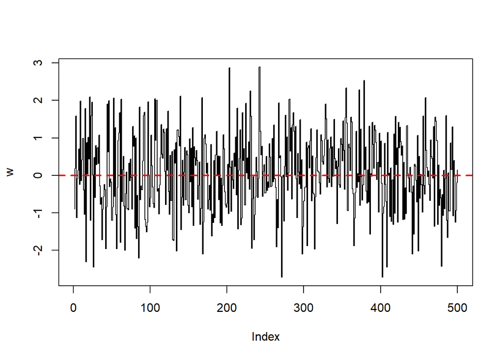

```r
library(tidyverse)

#White Noise
set.seed(2)
w <- rnorm(500)
plot(w,type='s')
abline(h=0,col='red',lty=2,lwd=2)
```

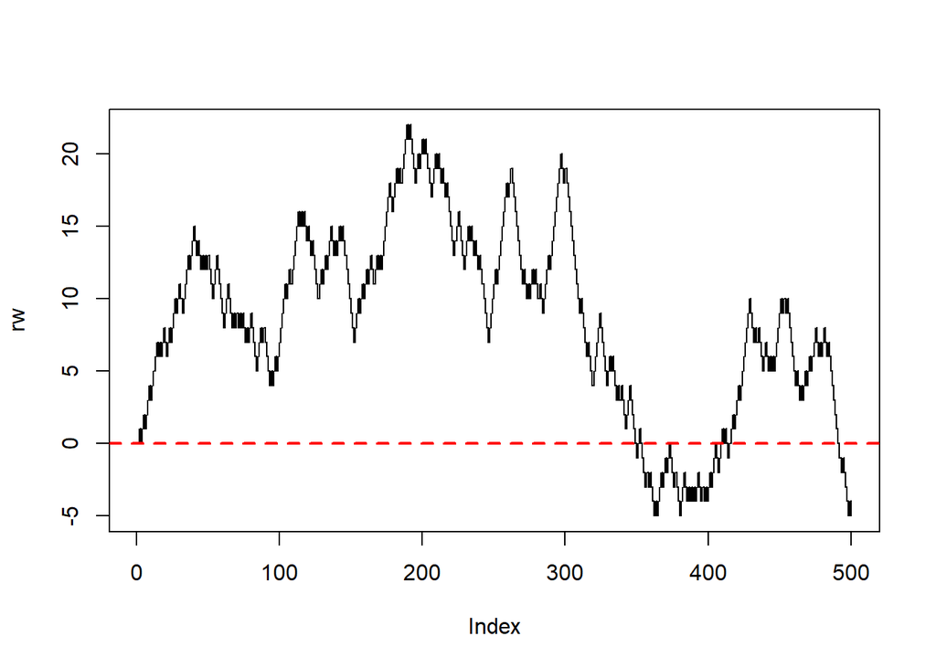

```r
#Random Walk
rw <- c(0)
for(i in 2:500){
  rw[i] <- rw[i-1]+sample(c(-1,1),1)
}
plot(rw,type='s')
abline(h=0,col='red',lty=2,lwd=2)
```

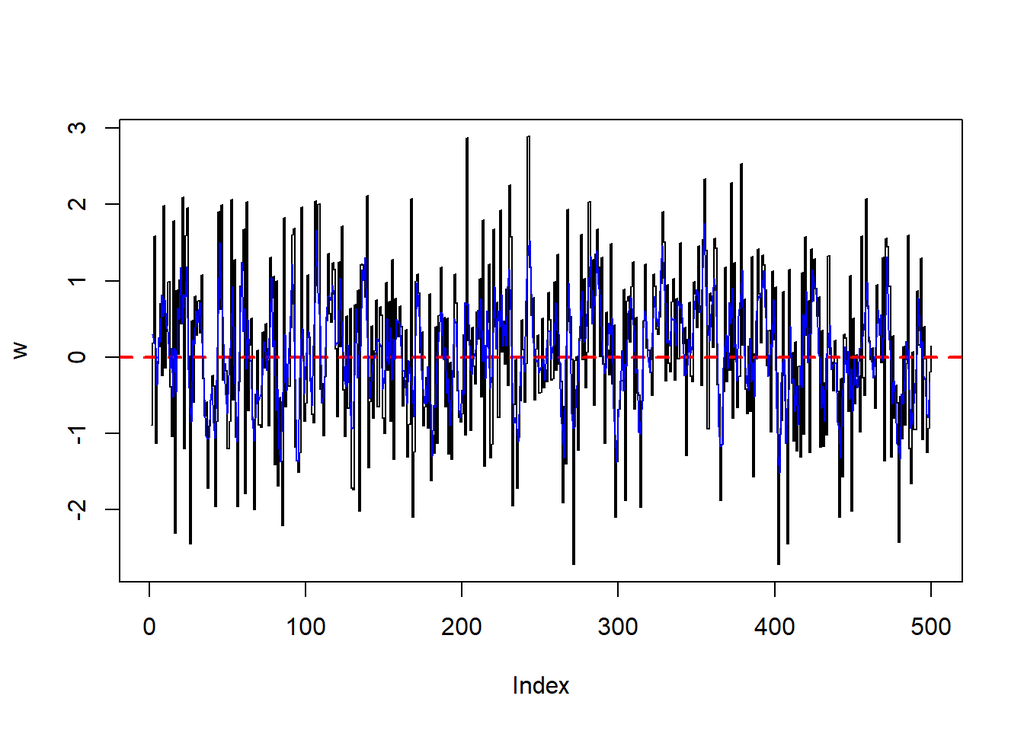

```r
#White Noise Moving average

w3 <- stats::filter(w, filter = rep(1/3, 3), sides = 2)
plot(w,type='s')
abline(h=0,col='red',lty=2,lwd=2)
lines(w3, col = "blue")
```

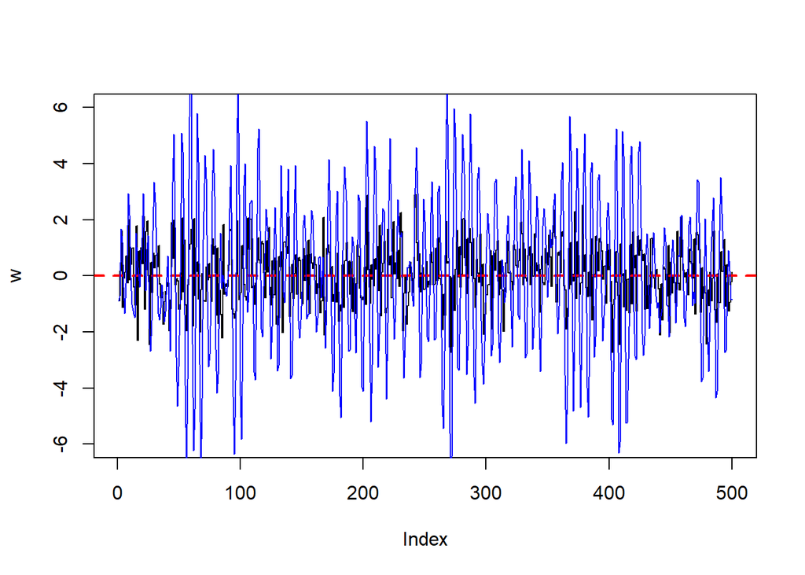

```r
#White Noise Autoregressive
war <- stats::filter(w, filter =c(1,-0.9), method = "recursive")
plot(w,type='s', ylim=c(-6,6))
abline(h=0,col='red',lty=2,lwd=2)
lines(war, col = "blue")
```

The above four simulations are of Gaussian white noise, a random walk, a Moving Average with Gaussian White Noise, and an Autoregressive Stochastic Process with Gaussian White Noise. These models can model basic signals (signal processing applications such as seismic detection and stock market fluctuations). We’ll see some of these return when we do an introductory formal analysis of time series with real data.

### Monte Carlo Simulation Example: Approximating Pi

Monte Carlo sampling methods are the backbone for many Bayesian statistical methodologies and for today’s growing complexity of Machine Learning models. Here, we’ll take a look at a simple, fun example to approximate pi. We’ll do this by sampling two times from the U(-0.5, 0.5) distribution and calculating the ratio of samples within a circle of radius 0.5 within a unit square divided by the total number of samples. Our approximation increases in precision as more samples are ran (think of the CLt and LLN theorems playing a role here).

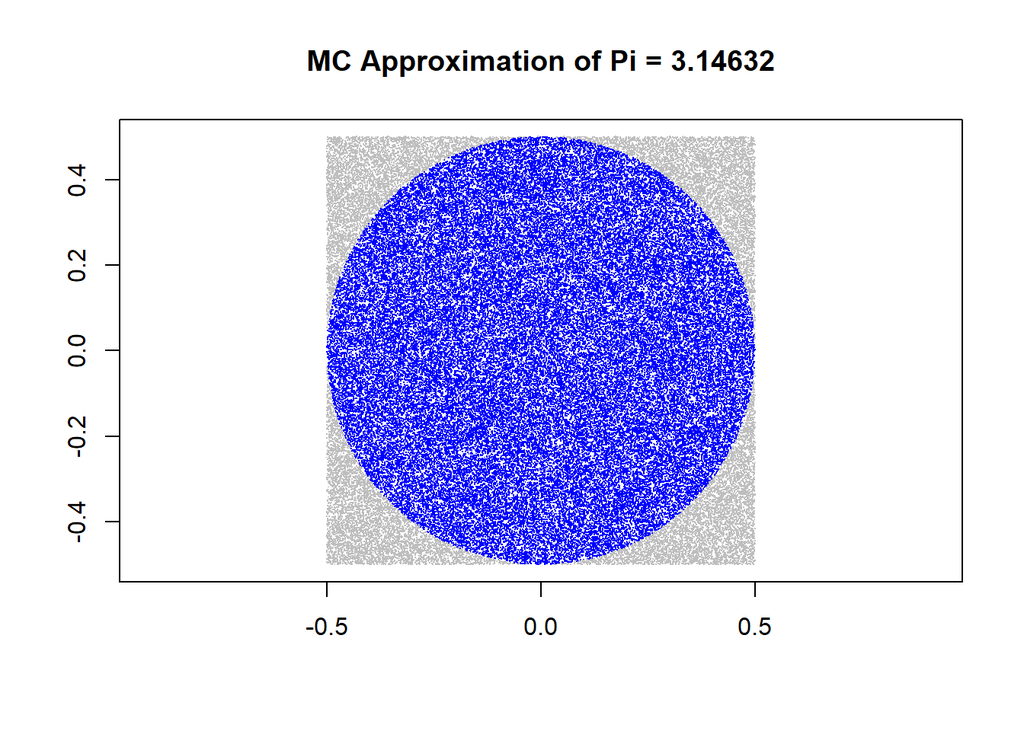

```r
set.seed(123)
runs = 100000
#runif samples from a uniform distribution
xs = runif(runs,min=-0.5,max=0.5)
ys = runif(runs,min=-0.5,max=0.5)
in.circle = xs^2 + ys^2 <= 0.5^2
mc.pi = (sum(in.circle)/runs)*4
plot(xs,ys,pch='.',col=ifelse(in.circle,"blue","grey")
     ,xlab='',ylab='',asp=1,
     main=paste("MC Approximation of Pi =",mc.pi))
```